# Section 5: Linear Model Selection and Regularization

Pablo Arés Gastesi

2026-07-06

# 1 Introduction

Section 2 reviewed the linear model and established that training error is an unreliable guide to predictive performance. This section picks up from there: when we have many predictors, fitting OLS with all of them tends to **overfit** — the model memorises the training data but generalises poorly to new observations. Three approaches address this:

1. **Subset Selection** — keep only a subset of the predictors.
2. **Ridge Regression** — shrink all coefficients toward zero (but never exactly zero).
3. **The Lasso** — shrink coefficients, setting some exactly to zero (automatic variable selection).

We will use the `Hitters` dataset (MLB player salaries) from the `ISLR2` package throughout.

```r
data(Hitters)

# Remove rows with missing salary
Hitters <- na.omit(Hitters)
cat("Observations:", nrow(Hitters), "| Predictors:", ncol(Hitters) - 1)
```

```
## Observations: 263 | Predictors: 19
```

# 2 Subset Selection

The idea: find the subset of predictors that gives the best model according to some criterion.

## 2.1 Best Subset Selection

Fit **all** $2^p$ possible models (one per subset of predictors) and pick the best one at each size $k$.

```r
regfit_full <- regsubsets(Salary ~ ., data = Hitters, nvmax = 19)
reg_summary <- summary(regfit_full)
```

For each model size we get RSS, $R^2$, adjusted $R^2$, $C_p$, and BIC. Let’s visualise them to pick the optimal number of predictors.

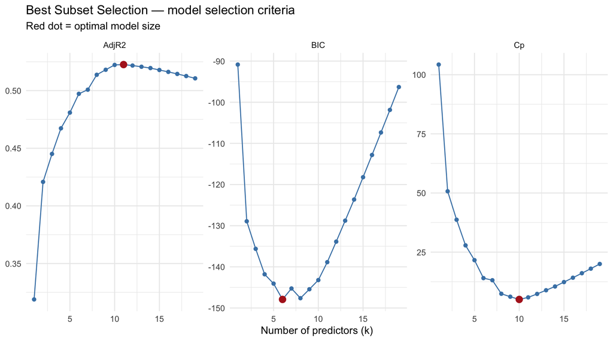

```r
metrics_df <- data.frame(
  k      = 1:19,
  AdjR2  = reg_summary$adjr2,
  Cp     = reg_summary$cp,
  BIC    = reg_summary$bic
)

# Find optimal k for each criterion
best_adjr2 <- which.max(metrics_df$AdjR2)
best_cp    <- which.min(metrics_df$Cp)
best_bic   <- which.min(metrics_df$BIC)

metrics_long <- metrics_df %>%
  pivot_longer(-k, names_to = "Criterion", values_to = "Value")

# Annotation for best points
best_points <- data.frame(
  k         = c(best_adjr2, best_cp, best_bic),
  Criterion = c("AdjR2", "Cp", "BIC"),
  Value     = c(metrics_df$AdjR2[best_adjr2],
                metrics_df$Cp[best_cp],
                metrics_df$BIC[best_bic])
)

ggplot(metrics_long, aes(x = k, y = Value)) +
  geom_line(colour = "steelblue") +
  geom_point(colour = "steelblue") +
  geom_point(data = best_points, colour = "firebrick", size = 3) +
  facet_wrap(~ Criterion, scales = "free_y") +
  labs(
    title = "Best Subset Selection — model selection criteria",
    subtitle = "Red dot = optimal model size",
    x = "Number of predictors (k)", y = NULL
  ) +
  theme_minimal()
```

> **Interpretation.** - **Adjusted $R^2$**: higher is better (penalises for adding useless predictors). - **$C_p$**: lower is better (estimates test MSE up to a constant). - **BIC**: lower is better (stronger penalty than $C_p$, tends to pick sparser models).

```r
cat("Optimal k by Adj R²:", best_adjr2,
    "| by Cp:", best_cp,
    "| by BIC:", best_bic, "\n")
```

```
## Optimal k by Adj R²: 11 | by Cp: 10 | by BIC: 6
```

```r
# Coefficients of the BIC-selected model
coef(regfit_full, best_bic)
```

```
##  (Intercept)        AtBat         Hits        Walks         CRBI    DivisionW
##   91.5117981   -1.8685892    7.6043976    3.6976468    0.6430169 -122.9515338
##      PutOuts
##    0.2643076
```

## 2.2 Stepwise Selection

Best subset is infeasible for large $p$ (too many models). **Forward** and **backward** stepwise search greedily, so they only evaluate $O(p^2)$ models.

```r
regfit_fwd <- regsubsets(Salary ~ ., data = Hitters, nvmax = 19, method = "forward")
regfit_bwd <- regsubsets(Salary ~ ., data = Hitters, nvmax = 19, method = "backward")

# Compare which predictor enters 7th in each method
cat("Forward  — 7-predictor model:\n");  print(coef(regfit_fwd, 7))
```

```
## Forward  — 7-predictor model:
```

```
##  (Intercept)        AtBat         Hits        Walks         CRBI       CWalks
##  109.7873062   -1.9588851    7.4498772    4.9131401    0.8537622   -0.3053070
##    DivisionW      PutOuts
## -127.1223928    0.2533404
```

```r
cat("\nBackward — 7-predictor model:\n"); print(coef(regfit_bwd, 7))
```

```
##
## Backward — 7-predictor model:
```

```
##  (Intercept)        AtBat         Hits        Walks        CRuns       CWalks
##  105.6487488   -1.9762838    6.7574914    6.0558691    1.1293095   -0.7163346
##    DivisionW      PutOuts
## -116.1692169    0.3028847
```

> The three methods can disagree because forward/backward greedy search is not guaranteed to find the globally best subset.

## 2.3 Choosing with Cross-Validation

$C_p$ / BIC are indirect proxies. We can estimate test error directly via **$k$-fold cross-validation**.

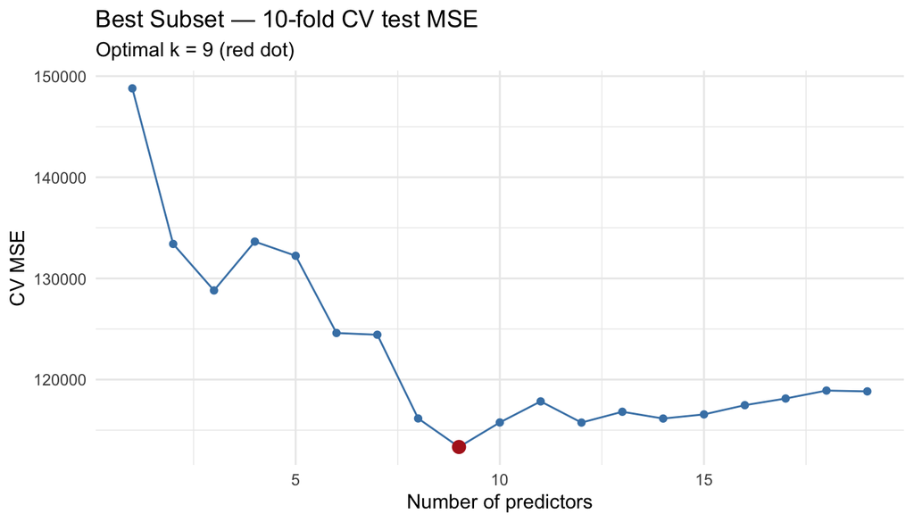

```r
set.seed(42)
k_folds <- 10
n       <- nrow(Hitters)
folds   <- sample(rep(1:k_folds, length.out = n))
cv_errors <- matrix(NA, k_folds, 19)

predict.regsubsets <- function(object, newdata, id) {
  form  <- as.formula(object$call[[2]])
  mat   <- model.matrix(form, newdata)
  coefi <- coef(object, id = id)
  mat[, names(coefi)] %*% coefi
}

for (j in 1:k_folds) {
  fit <- regsubsets(Salary ~ ., data = Hitters[folds != j, ], nvmax = 19)
  for (i in 1:19) {
    pred <- predict.regsubsets(fit, Hitters[folds == j, ], id = i)
    cv_errors[j, i] <- mean((Hitters$Salary[folds == j] - pred)^2)
  }
}

cv_df <- data.frame(k = 1:19, CV_MSE = colMeans(cv_errors))
best_cv <- which.min(cv_df$CV_MSE)

ggplot(cv_df, aes(x = k, y = CV_MSE)) +
  geom_line(colour = "steelblue") +
  geom_point(colour = "steelblue") +
  geom_point(data = cv_df[best_cv, ], colour = "firebrick", size = 3) +
  labs(
    title    = "Best Subset — 10-fold CV test MSE",
    subtitle = paste0("Optimal k = ", best_cv, " (red dot)"),
    x = "Number of predictors", y = "CV MSE"
  ) +
  theme_minimal()
```

```r
coef(regfit_full, best_cv)
```

```
##   (Intercept)         AtBat          Hits         Walks        CAtBat
##  146.24960033   -1.93676754    6.65672102    5.55204413   -0.09953904
##         CRuns          CRBI        CWalks     DivisionW       PutOuts
##    1.25067124    0.66176849   -0.77798498 -115.34950146    0.27773062
```

# 3 Ridge Regression

## 3.1 The Idea

OLS minimises $\text{RSS}$. Ridge minimises:

$$\text{RSS} + \lambda \sum_{j=1}^{p} \beta_j^2$$

The extra term ($L_2$ penalty) **shrinks** all coefficients toward zero. As $\lambda \to \infty$, all $\hat\beta \to 0$. As $\lambda \to 0$, we recover OLS.

> **Key property**: predictors must be on the same scale, so `glmnet` standardises by default.

## 3.2 Fitting the Ridge Path

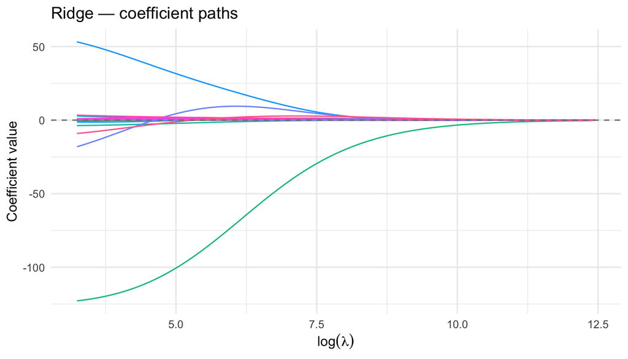

```r
x <- model.matrix(Salary ~ ., Hitters)[, -1]   # drop intercept column
y <- Hitters$Salary

# alpha = 0 → Ridge
ridge_mod <- glmnet(x, y, alpha = 0)

# Coefficient paths
tidy_ridge <- as.data.frame(as.matrix(t(coef(ridge_mod)[-1, ])))  # drop intercept
tidy_ridge$log_lambda <- log(ridge_mod$lambda)

tidy_ridge_long <- tidy_ridge %>%
  pivot_longer(-log_lambda, names_to = "Predictor", values_to = "Coefficient")

ggplot(tidy_ridge_long, aes(x = log_lambda, y = Coefficient,
                             colour = Predictor)) +
  geom_line(show.legend = FALSE) +
  geom_hline(yintercept = 0, linetype = "dashed", colour = "grey50") +
  labs(
    title = "Ridge — coefficient paths",
    x = expression(log(lambda)), y = "Coefficient value"
  ) +
  theme_minimal()
```

> As $\log\lambda$ increases (stronger regularisation) all coefficients shrink toward zero but **never reach it exactly**.

## 3.3 Choosing $\lambda$ by Cross-Validation

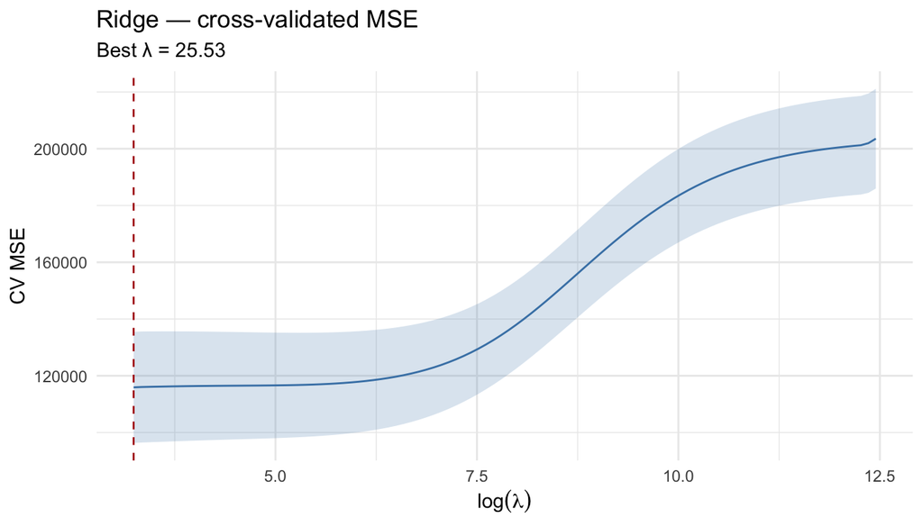

```r
set.seed(42)
cv_ridge <- cv.glmnet(x, y, alpha = 0)

# Extract CV curve data
cv_ridge_df <- data.frame(
  log_lambda = log(cv_ridge$lambda),
  cvm        = cv_ridge$cvm,
  cvup       = cv_ridge$cvup,
  cvlo       = cv_ridge$cvlo
)

best_lam_ridge <- cv_ridge$lambda.min

ggplot(cv_ridge_df, aes(x = log_lambda, y = cvm)) +
  geom_ribbon(aes(ymin = cvlo, ymax = cvup), fill = "steelblue", alpha = 0.2) +
  geom_line(colour = "steelblue") +
  geom_vline(xintercept = log(best_lam_ridge),
             linetype = "dashed", colour = "firebrick") +
  labs(
    title    = "Ridge — cross-validated MSE",
    subtitle = paste0("Best λ = ", round(best_lam_ridge, 2)),
    x = expression(log(lambda)), y = "CV MSE"
  ) +
  theme_minimal()
```

```r
ridge_coef <- predict(cv_ridge, type = "coefficients",
                      s = best_lam_ridge)[1:20, ]
ridge_coef
```

```
##   (Intercept)         AtBat          Hits         HmRun          Runs
##  8.112693e+01 -6.815959e-01  2.772312e+00 -1.365680e+00  1.014826e+00
##           RBI         Walks         Years        CAtBat         CHits
##  7.130224e-01  3.378558e+00 -9.066800e+00 -1.199478e-03  1.361029e-01
##        CHmRun         CRuns          CRBI        CWalks       LeagueN
##  6.979958e-01  2.958896e-01  2.570711e-01 -2.789666e-01  5.321272e+01
##     DivisionW       PutOuts       Assists        Errors    NewLeagueN
## -1.228345e+02  2.638876e-01  1.698796e-01 -3.685645e+00 -1.810510e+01
```

# 4 The Lasso

## 4.1 The Idea

The Lasso replaces the $L_2$ penalty with an $L_1$ penalty:

$$\text{RSS} + \lambda \sum_{j=1}^{p} |\beta_j|$$

The $L_1$ penalty has a crucial geometric property: it pushes some coefficients to **exactly zero**, performing automatic variable selection.

| Method | Penalty | Zeroes out predictors? |
| --- | --- | --- |
| Ridge | $\sum \beta_j^2$ | No |
| Lasso | $\sum \|\beta_j\|$ | Yes |

## 4.2 Fitting the Lasso Path

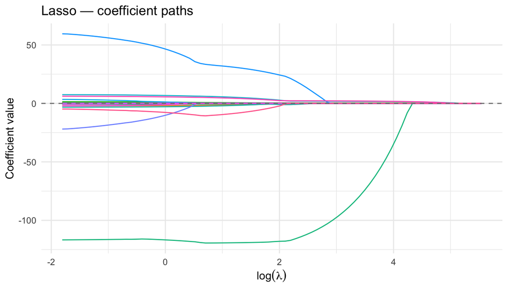

```r
# alpha = 1 → Lasso
lasso_mod <- glmnet(x, y, alpha = 1)

tidy_lasso <- as.data.frame(as.matrix(t(coef(lasso_mod)[-1, ])))
tidy_lasso$log_lambda <- log(lasso_mod$lambda)

tidy_lasso_long <- tidy_lasso %>%
  pivot_longer(-log_lambda, names_to = "Predictor", values_to = "Coefficient")

ggplot(tidy_lasso_long, aes(x = log_lambda, y = Coefficient,
                             colour = Predictor)) +
  geom_line(show.legend = FALSE) +
  geom_hline(yintercept = 0, linetype = "dashed", colour = "grey50") +
  labs(
    title = "Lasso — coefficient paths",
    x = expression(log(lambda)), y = "Coefficient value"
  ) +
  theme_minimal()
```

> Notice how coefficients hit exactly zero as $\lambda$ grows — the model becomes progressively sparser.

## 4.3 Choosing $\lambda$ by Cross-Validation

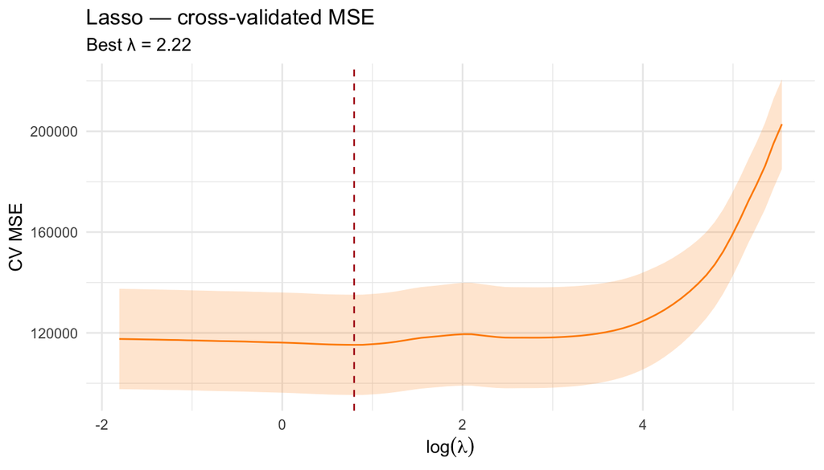

```r
set.seed(42)
cv_lasso <- cv.glmnet(x, y, alpha = 1)

cv_lasso_df <- data.frame(
  log_lambda = log(cv_lasso$lambda),
  cvm        = cv_lasso$cvm,
  cvup       = cv_lasso$cvup,
  cvlo       = cv_lasso$cvlo
)

best_lam_lasso <- cv_lasso$lambda.min

ggplot(cv_lasso_df, aes(x = log_lambda, y = cvm)) +
  geom_ribbon(aes(ymin = cvlo, ymax = cvup), fill = "darkorange", alpha = 0.2) +
  geom_line(colour = "darkorange") +
  geom_vline(xintercept = log(best_lam_lasso),
             linetype = "dashed", colour = "firebrick") +
  labs(
    title    = "Lasso — cross-validated MSE",
    subtitle = paste0("Best λ = ", round(best_lam_lasso, 2)),
    x = expression(log(lambda)), y = "CV MSE"
  ) +
  theme_minimal()
```

```r
lasso_coef <- predict(cv_lasso, type = "coefficients",
                      s = best_lam_lasso)[1:20, ]
lasso_coef
```

```
##   (Intercept)         AtBat          Hits         HmRun          Runs
##  134.48030406   -1.67572220    5.94122316    0.04746835    0.00000000
##           RBI         Walks         Years        CAtBat         CHits
##    0.00000000    4.95676182  -10.26657309    0.00000000    0.00000000
##        CHmRun         CRuns          CRBI        CWalks       LeagueN
##    0.56236426    0.70135135    0.38727139   -0.58111548   32.92255640
##     DivisionW       PutOuts       Assists        Errors    NewLeagueN
## -119.37941356    0.27580087    0.19782326   -2.26242857    0.00000000
```

> The Lasso sets several coefficients to exactly zero — those predictors are dropped from the model entirely.

# 5 Comparing the Three Approaches

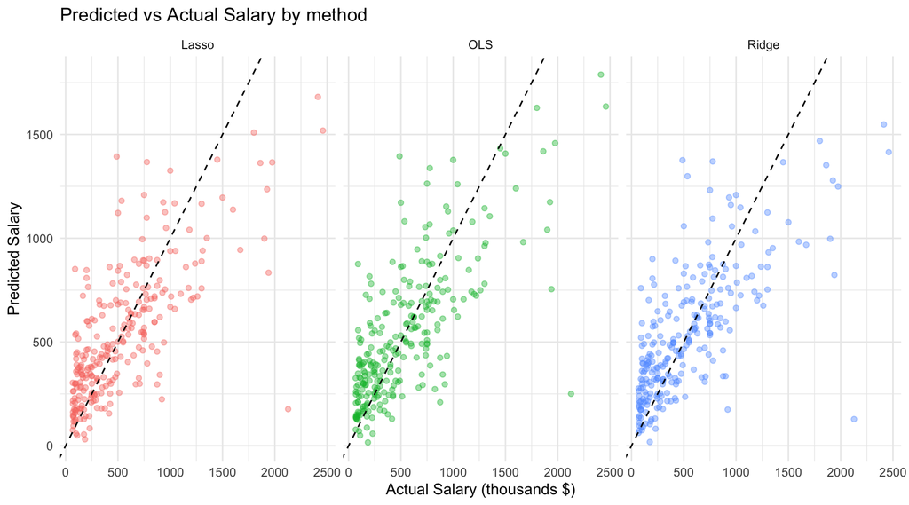

```r
# Get predictions on full data (illustrative — ideally use a held-out set)
pred_ridge <- as.vector(predict(cv_ridge, newx = x, s = best_lam_ridge))
pred_lasso <- as.vector(predict(cv_lasso, newx = x, s = best_lam_lasso))
pred_ols   <- fitted(lm(Salary ~ ., data = Hitters))

compare_df <- data.frame(
  Actual = y,
  Ridge  = pred_ridge,
  Lasso  = pred_lasso,
  OLS    = pred_ols
) %>%
  pivot_longer(-Actual, names_to = "Method", values_to = "Predicted")

ggplot(compare_df, aes(x = Actual, y = Predicted, colour = Method)) +
  geom_point(alpha = 0.4, size = 1.5) +
  geom_abline(slope = 1, intercept = 0, linetype = "dashed") +
  facet_wrap(~ Method) +
  labs(
    title = "Predicted vs Actual Salary by method",
    x = "Actual Salary (thousands $)", y = "Predicted Salary"
  ) +
  theme_minimal() +
  theme(legend.position = "none")
```

```r
mse <- function(actual, predicted) mean((actual - predicted)^2)
data.frame(
  Method    = c("OLS", "Ridge", "Lasso"),
  Train_MSE = c(mse(y, pred_ols), mse(y, pred_ridge), mse(y, pred_lasso))
)
```

| Method | Train_MSE |
| --- | --- |
| OLS | 92017.87 |
| Ridge | 98033.07 |
| Lasso | 94175.60 |

> Training MSE alone doesn’t tell the full story — regularised methods accept slightly higher training error in exchange for better generalisation. Always compare on a **test set** or via **cross-validation**.

# 6 Simulation Studies

Simulations let us **know the truth** — we generate data from a controlled process and check whether each method recovers it.

## 6.1 Ridge vs Lasso: sparse vs dense signals

We simulate two worlds:

- **Sparse**: only 3 of 20 predictors truly matter → Lasso should win.
- **Dense**: all 20 predictors have small effects → Ridge should win.

```r
set.seed(123)
n <- 100; p <- 20

sim_data <- function(n, p, type = c("sparse", "dense"), snr = 2) {
  type <- match.arg(type)
  X    <- matrix(rnorm(n * p), n, p)
  if (type == "sparse") {
    beta <- c(3, -2, 1.5, rep(0, p - 3))          # only 3 non-zero
  } else {
    beta <- rep(0.5, p)                             # all small but non-zero
  }
  sigma <- sqrt(sum((X %*% beta)^2) / (n * snr))
  y     <- X %*% beta + rnorm(n, sd = sigma)
  list(X = X, y = y, beta = beta)
}
```

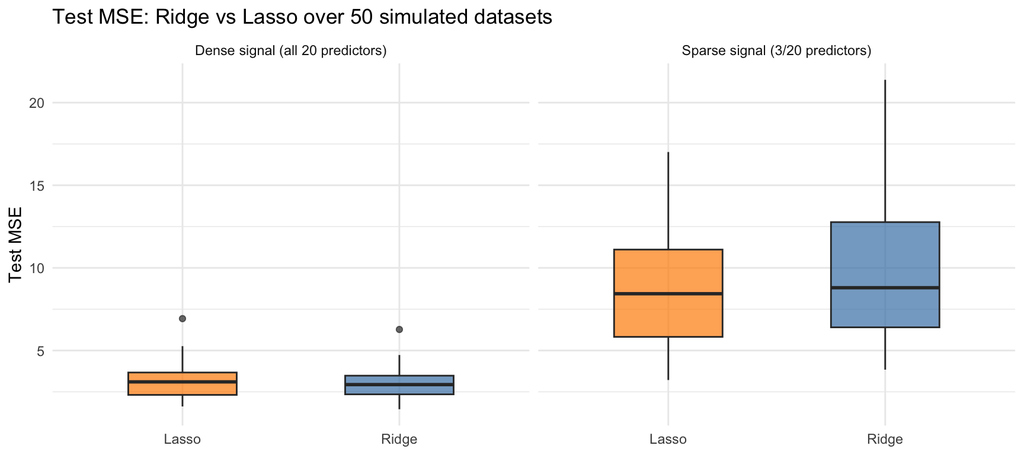

```r
run_sim <- function(type, n_rep = 50) {
  results <- replicate(n_rep, {
    d        <- sim_data(n, p, type)
    idx      <- sample(n, 0.8 * n)
    X_tr     <- d$X[idx, ];  y_tr <- d$y[idx]
    X_te     <- d$X[-idx, ]; y_te <- d$y[-idx]

    cv_r <- cv.glmnet(X_tr, y_tr, alpha = 0, nfolds = 5)
    cv_l <- cv.glmnet(X_tr, y_tr, alpha = 1, nfolds = 5)

    mse_ridge <- mean((y_te - predict(cv_r, X_te, s = "lambda.min"))^2)
    mse_lasso <- mean((y_te - predict(cv_l, X_te, s = "lambda.min"))^2)
    c(Ridge = mse_ridge, Lasso = mse_lasso)
  }, simplify = FALSE)

  as.data.frame(do.call(rbind, results)) %>%
    pivot_longer(everything(), names_to = "Method", values_to = "Test_MSE") %>%
    mutate(Setting = type)
}

sim_df <- bind_rows(run_sim("sparse"), run_sim("dense"))

ggplot(sim_df, aes(x = Method, y = Test_MSE, fill = Method)) +
  geom_boxplot(alpha = 0.7, width = 0.5) +
  facet_wrap(~ Setting, labeller = labeller(
    Setting = c(sparse = "Sparse signal (3/20 predictors)",
                dense  = "Dense signal (all 20 predictors)")
  )) +
  scale_fill_manual(values = c(Ridge = "steelblue", Lasso = "darkorange")) +
  labs(
    title   = "Test MSE: Ridge vs Lasso over 50 simulated datasets",
    x = NULL, y = "Test MSE"
  ) +
  theme_minimal() +
  theme(legend.position = "none")
```

> **Result**: Lasso wins in the sparse setting (it zeros out irrelevant predictors). Ridge wins in the dense setting (nothing should be zeroed, and shrinking everything equally helps more).

## 6.2 Coefficient Recovery

How well do Ridge and Lasso recover the true $\beta$? We look at one sparse dataset.

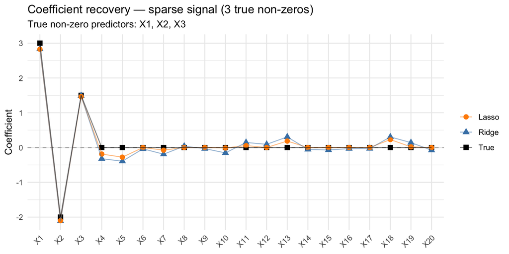

```r
set.seed(7)
d    <- sim_data(200, p, "sparse")
cv_r <- cv.glmnet(d$X, d$y, alpha = 0)
cv_l <- cv.glmnet(d$X, d$y, alpha = 1)

coef_df <- data.frame(
  Predictor = paste0("X", 1:p),
  True      = d$beta,
  Ridge     = as.vector(coef(cv_r, s = "lambda.min"))[-1],
  Lasso     = as.vector(coef(cv_l, s = "lambda.min"))[-1]
) %>%
  pivot_longer(-Predictor, names_to = "Source", values_to = "Coefficient") %>%
  mutate(Predictor = factor(Predictor, levels = paste0("X", 1:p)))

ggplot(coef_df, aes(x = Predictor, y = Coefficient, colour = Source,
                    shape = Source, group = Source)) +
  geom_hline(yintercept = 0, linetype = "dashed", colour = "grey70") +
  geom_point(size = 2.5) +
  geom_line(alpha = 0.5) +
  scale_colour_manual(values = c(True = "black", Ridge = "steelblue",
                                 Lasso = "darkorange")) +
  labs(
    title    = "Coefficient recovery — sparse signal (3 true non-zeros)",
    subtitle = "True non-zero predictors: X1, X2, X3",
    x = NULL, y = "Coefficient", colour = NULL, shape = NULL
  ) +
  theme_minimal() +
  theme(axis.text.x = element_text(angle = 45, hjust = 1))
```

## 6.3 Bias–Variance Trade-off as a Function of $\lambda$

As $\lambda$ increases, bias grows and variance shrinks. We can trace this directly in simulation.

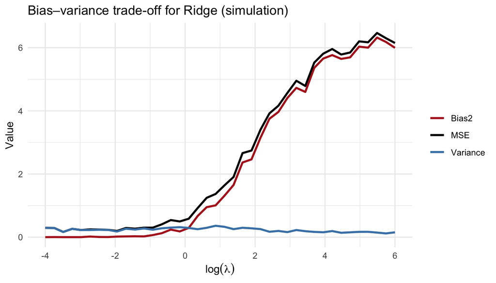

```r
set.seed(42)
n_rep   <- 100
lambdas <- exp(seq(-4, 6, length.out = 40))

# One fixed test point: X = rep(1, p), true beta is sparse
beta_true <- c(3, -2, 1.5, rep(0, p - 3))
x_test    <- matrix(rep(1, p), nrow = 1)
true_y    <- x_test %*% beta_true

bv_results <- sapply(lambdas, function(lam) {
  preds <- replicate(n_rep, {
    X <- matrix(rnorm(n * p), n, p)
    y <- X %*% beta_true + rnorm(n)
    fit  <- glmnet(X, y, alpha = 0, lambda = lam)
    as.vector(predict(fit, x_test))
  })
  bias2   <- (mean(preds) - true_y)^2
  variance <- var(preds)
  c(Bias2 = bias2, Variance = variance, MSE = bias2 + variance)
})

bv_df <- as.data.frame(t(bv_results)) %>%
  mutate(log_lambda = log(lambdas)) %>%
  pivot_longer(-log_lambda, names_to = "Component", values_to = "Value")

ggplot(bv_df, aes(x = log_lambda, y = Value, colour = Component)) +
  geom_line(linewidth = 1) +
  scale_colour_manual(values = c(Bias2 = "firebrick", Variance = "steelblue",
                                  MSE = "black")) +
  labs(
    title   = "Bias–variance trade-off for Ridge (simulation)",
    x = expression(log(lambda)), y = "Value", colour = NULL
  ) +
  theme_minimal()
```

# 7 Summary

| Method | Selects variables | Handles multicollinearity | Best when |
| --- | --- | --- | --- |
| Best Subset | ✓ | ✗ | $p$ is small |
| Stepwise | ✓ | ✗ | $p$ is moderate |
| Ridge | ✗ | ✓ ✓ | All predictors matter |
| Lasso | ✓ | ✓ | Sparse true model |

**Key tuning principle**: always choose $\lambda$ (ridge/lasso) or model size (subset selection) using cross-validation, not training error.